# Customer Churn: Loyalty Rewards and A/B Testing

Customer acquisition and retention are key drivers of sustainable growth. Whilst acquisition grows the customer/revenue base, retention increases customer lifetime value (LTV). With a limited marketing budget it is essential to consider which (or what combination of the two) offers the best return on investment (ROI). Naturally, this will depend on a variety of factors relating to the industry and the organisation, including its' strengths, weaknesses, needs and objectives. At the risk of making a sweeping generalisation, retention is often cheaper and yields a greater ROI, particularly for subscription based businesses (i.e. telco's, SaaS businesses) whereas businesses that depend on large, one-time customer purchases may be better served by focusing on acquisition initiatives.

This notebook will focus on the results of a retention campaign carried out by a fictional telecommunications company to demonstrate how A/B testing can be used to evaluate the success of a loyalty reward scheme. The notebook will take a computational approach to A/B testing which uses intuitive and 'formula-light' resampling methods.

The data for the notebook is retrieved from the [IBM Accelerator Catalog](https://community.ibm.com/accelerators/). Links to the specific datasets used in the notebook can be found in the 'import' section of the notebook.

## Import libraries and data

```python
# import libraries
import pandas as pd
import numpy as np
import matplotlib.pyplot as plt
import seaborn as sns
import plotly.graph_objects as go
import plotly.io as pio
# change default render to static png image (due to issues converting notebook to html)
pio.renderers.default = 'png'
from random import sample
```

```python
# import data
status = pd.read_excel("https://public.dhe.ibm.com/software/data/sw-library/cognos/mobile/C11/data/Telco_customer_churn_status.xlsx",\
                       index_col='Customer ID')
services = pd.read_excel('https://public.dhe.ibm.com/software/data/sw-library/cognos/mobile/C11/data/Telco_customer_churn_services.xlsx',\
                         index_col='Customer ID')
```

# The data

The IBM Telco Churn Services and Status datasets contain all sorts of useful information, the focus of this notebook however will be on the below variables:

From Status dataset:

- Churn Value - values of 0 or 1, indicating whether the customer has churned (1) or not (0)

From Services dataset:

- Tenure in Months
- Offer
- Monthly charge

```python
# define merge function that ignores duplicate columns
def merge(left, right):
  left_col = left.columns
  right_col = right.columns
  difference = right_col.difference(left_col)
  merged =  pd.merge(left, right[difference], left_index=True, right_index=True)
  return merged

churn = merge(status, services)
churn = churn[['Churn Value', 'Tenure in Months', 'Offer', 'Monthly Charge']]
```

```python
# inspect
churn.head(3)
```

| Customer ID | Churn Value | Tenure in Months | Offer | Monthly Charge |
| --- | --- | --- | --- | --- |
| 8779-QRDMV | 1 | 1 | None | 39.65 |
| 7495-OOKFY | 1 | 8 | Offer E | 80.65 |
| 1658-BYGOY | 1 | 18 | Offer D | 95.45 |

# Customer Acquisition & Churn

Customer Acquisition and Retention are two sides of the same coin and both key to sustainable growth. Waterfall charts are practical data visualisation tools to communicate the gradual transition from one value to another through a series of cumulative steps.

```python
# count customers at start of period i.e. customers with tenure > 3
Q2 = churn[churn['Tenure in Months'] > 3]['Monthly Charge'].agg(['count', 'sum']).round()

#count customers that churn during Q3
churned = churn[churn['Churn Value'] == 1]['Monthly Charge'].agg(['count', 'sum']).round()

# count customers that joined during Q3 i.e. customers with tenure < 3
onboarded = churn[(churn['Tenure in Months'] <= 3)]['Monthly Charge'].agg(['count', 'sum']).round()

# count customers at end of Q3 i.e. customers with churn value = 0
Q3 = churn[churn['Churn Value'] == 0]['Monthly Charge'].agg(['count', 'sum']).round()

print('Customers at Q3 start                 : ', Q2[0], ' ,  £', Q2[1], ' (count, total monthly charge)')
print('customers churned                     : ', churned[0], ' ,  £', churned[1])
print('customers onboarded                   : ', onboarded[0], ' ,  £', onboarded[1])
print('Customers at Q3 end                   : ', Q3[0], ' ,  £', Q3[1])
```

```
Customers at Q3 start                 :  5992.0  ,  £ 399951.0  (count, total monthly charge)
customers churned                     :  1869.0  ,  £ 139131.0
customers onboarded                   :  1051.0  ,  £ 56166.0
Customers at Q3 end                   :  5174.0  ,  £ 316986.0
```

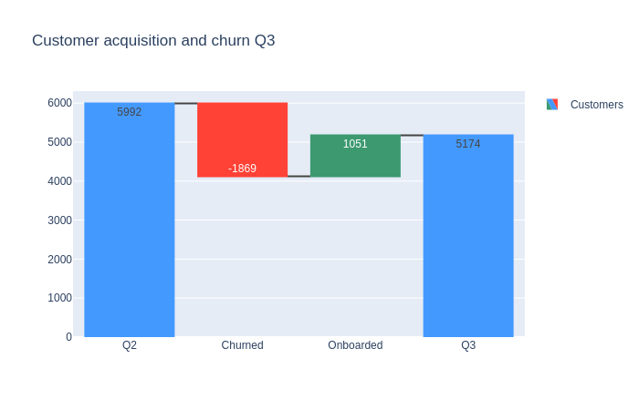

```python
# plot waterfall chart for above figures
fig = go.Figure(go.Waterfall(
    name = "Customers", orientation = "v",
    measure = ["absolute", "relative", "relative", "total"],
    x = ['Q2', 'Churned', 'Onboarded', 'Q3'],
    textposition = "inside",
    text = [str(int(Q2[0])), str(int(-churned[0])), str(int(onboarded[0])), str(int(Q3[0]))],
    y = [Q2[0], -churned[0], onboarded[0], Q3[0]]))

fig.update_layout(
        title = "Customer acquisition and churn Q3",
        showlegend = True
)

fig.show()
```

The waterfall graph illustrates that the company has lost more customers than it has gained during Q3. This is not a sustainable situation to be in and illustrates both the importance of customer acquisition and customer retention. With this situation in mind, this notebook will now focus on how this business can reduce customer churn using A/B testing to evaluate the success of its loyalty reward program.

# Loyalty Rewards & Evaluating Success

The variable 'Offer' contains 6 unique values including 5 'offers' and a 'None' value.

For the purpose of demonstration, this notebook is going to assume that these offers are loyalty rewards that have been allocated to customers at random as part of an experiment to see whether loyalty rewards might reduce customer churn.

```python
churn['Offer'].value_counts()
```

```
None       3877
Offer B     824
Offer E     805
Offer D     602
Offer A     520
Offer C     415
Name: Offer, dtype: int64
```

### Scenario 1: Loyalty Reward

In this scenario we are going to assume that all 5 of the rewards are identical and have been allocated at random to existing customers.

What we are trying to test and understand is whether the loyalty reward that was offered is likely to have reduced customer churn vs. the control group which did not receive any reward.

```python
# create new variable 'Reward'
churn['Reward'] = churn['Offer'].replace(dict.fromkeys(['Offer A','Offer B', 'Offer C','Offer D', 'Offer E'], 'Reward'),
    regex=True)
```

```python
# inspect churn rate for Reward and Control groups
reward = churn.groupby('Reward')['Churn Value'].agg(['mean', 'count']).transpose()
reward.round(3)
```

| Reward | None | Reward |
| --- | --- | --- |
| mean | 0.271 | 0.258 |
| count | 3877.000 | 3166.000 |

```python
print('Reward vs. None  (% points)           : ',((reward.iloc[0,1] - reward.iloc[0,0]) * 100).round(2), '%')
print('Reward vs. None  (% diff)             : ',((reward.iloc[0,1] - reward.iloc[0,0]) / reward.iloc[0,0] * 100).round(2), '%')
```

```
Reward vs. None  (% points)           :  -1.27 %
Reward vs. None  (% diff)             :  -4.69 %
```

The rewarded group exhibits a reduced churn vs. the control group. The churn rate is 1.27% points lower for the rewarded group vs. the control group which is equivalent to a 4.69% decrease in churn rate. For a high volume business, such a reduction could be large enough to be meaningful. However, before we jump to any conclusions, we need to consider the possibility that the observed effect isn't just a result of random chance.

## Permutation Testing - could the observed effect be a result of random chance?

Hypothesis Tests help us assess whether random chance might be responsible for the observed effect (i.e. the reduction in churn rate). They start with the baseline assumption that the difference between groups is due to random chance (the null hypothesis). The purpose of the test is to see if the null hypothesis can be rejected by showing that the outcomes for groups A and B are more different than what chance might produce.

Permutation testing provides an intuitive approach to hypothesis testing that involves:

1. Shuffling results from the groups A and B
2. Sampling the shuffled results with sample sizes equal to the sizes of groups A and B
3. Observing how often we get a difference as extreme as the observed difference

If the observed difference lies outside most of the permuted differences then we can reject the null hypothesis and conclude that the difference is 'statistically significant'.

```python
# calculate churn rate for reward group
reward = churn[churn.Reward == 'Reward']['Churn Value'].mean()

# calculate churn rate for control group
none = churn[churn.Reward == 'None']['Churn Value'].mean()

# calculate observed difference of means
ob_diff = reward - none
ob_diff
```

```
-0.012715707956490907
```

The observed difference of churn rate is 1.27% points

```python
def permute(df, group, A, B, outcome, iterations, func):
  #initialise list for test statistic replicates
  perm_reps = []
  #slice outcomes
  samples = df[outcome]
  #calculate group size for slicing
  nA = len(df[df[group] == A])
  # iterate calculations
  for i in range(iterations):
    # permute or 'shuffle' outcomes
    perm = np.random.permutation(samples)
    # slice permuted outcomes to create perm samples for A & B
    perm_A = perm[:nA]
    perm_B = perm[nA:]
    # calc test statistic and append to list
    perm_reps += [func(perm_A) - func(perm_B)]
  return np.array(perm_reps)
```

```python
reps = permute(churn, 'Reward', 'None', 'Reward', 'Churn Value', 10000, np.mean)
```

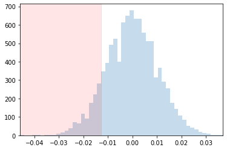

```python
# plot histogram of permutation replicates
plt.hist(reps, bins=50, alpha=0.25)

# shade area of graph where difference of means is as extreme as the observed value (one tail test)
plt.axvspan(np.min(reps), ob_diff, alpha=0.1, color='red')
plt.xlim(np.min(reps), np.max(reps))
plt.show()
```

Visually, we can see that the majority of the area under the graph lies to the right of the observed difference of means i.e. most of the permuted samples had either reduced reductions in churn rate or increased churn rates.

The p-value provides a more precise measure of statistical significance. It is simply calculated as the proportion of times the permutation test produced a difference equal or more extreme than the observed difference. Values of 0.05 and 0.10 are commonly used. Of course, the level chosen is somewhat arbitrary.

```python
# calculate p-value
p = np.sum(reps <= ob_diff) / len(reps)
print('p-value =' , p)
```

```
p-value = 0.1134
```

From a business perspective this doesn't really answer the more fundemental question: did the loyalty reward reduce churn?

So, rather than simply accept the null hypothesis, chalk the reduction down to random chance and leave it at that, let's extend our analysis by taking a closer look at the difference in churn rates across the two groups.

## Bootstrap Resampling - How reliable is our estimate?

Bootstrapping involves repeatedly re-sampling the dataset with replacement and calculating the churn rate reduction across these samples. In effect, this is simulating the drawing of multiple samples by using just one sample from a population. The variation in churn rate reduction will give us an indication of how uncertain the numbers are and enable us to calculate confidence intervals for our results and answer other key questions.

```python
# Create a list with bootstrapped means for each group
boot = []
for i in range(10000):
    boot_mean = churn.sample(frac=1, replace=True).groupby('Reward')['Churn Value'].mean()
    boot.append(boot_mean)

# Transform list to a DataFrame
boot = pd.DataFrame(boot)
```

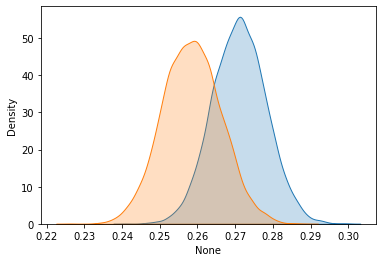

```python
# plot bootstrap distributions with a kernal density estimate
sns.kdeplot(boot['None'], shade=True)
sns.kdeplot(boot['Reward'], shade=True)
plt.show()
```

These two distributions represent the uncertainty over what the underlying churn rate could be for the two groups (control & reward). Just looking at the plot, we can see that there seems to be some evidence of a difference, albeit small, in churn rate between the two groups but also considerable overlap.

Let's focus on the difference in churn rate between the control group and the reward group for each of the samples taken.

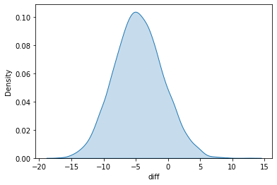

```python
# Adding a column with the % difference between the two AB-groups
boot['diff'] = (boot['Reward'] - boot['None'] ) / boot['None'] * 100

# Plot the bootstrap % difference
sns.kdeplot(boot['diff'], shade=True)
plt.show()
```

Looking at the plot, we can see that the distribution of the % reduction in churn is centered around -5% and that most of the distribution is below 0%, suggesting that a loyalty reward is likely to reduce churn.

```python
# Calculating the probability that churn is lower when a customer is given a loyalty reward
prob = (boot['diff'] < 0).sum() / len(boot['diff'])

# printing the probability
print('probability that churn is lower with reward : ', np.round(prob * 100, 2), '%')
```

```
probability that churn is lower with reward :  87.96 %
```

```python
# confidence interval
ci = np.percentile(boot['diff'], [5, 95])
print('confidence interval :', ci[0].round(2),'%  to ', ci[1].round(2), '%')
```

```
confidence interval : -10.76 %  to  1.85 %
```

### Scenario 2: Segmented Loyalty Reward A/B Test

A/B tests can also be applied to segments of the customer base. As discussed previously, the 'Offer' variable includes 5 offers ranging from A to E.

We don't have any context as to what these might be but let's once again assume that they are loyalty rewards that have been randomly allocated to customers. This time however, let's assume that these loyalty rewards are scaled to reflect the customers tenure. This is not an unreasonable assumption given the below table illustrating the min / max range of tenure within each offer group.

```python
churn.groupby('Offer')['Tenure in Months'].agg(['min','max', 'count']).round(2)
```

| Offer | min | max | count |
| --- | --- | --- | --- |
| None | 1 | 72 | 3877 |
| Offer A | 66 | 72 | 520 |
| Offer B | 40 | 65 | 824 |
| Offer C | 24 | 39 | 415 |
| Offer D | 10 | 23 | 602 |
| Offer E | 1 | 10 | 805 |

Given our assumption, lets create a new variable 'tenure' to group all customers by the same tenure bands used by the offers. This will enable us to then filter the customers and apply A/B tests for each tenure segment.

```python
tenure = []
for row in churn['Tenure in Months']:
    if row <= 10    :    tenure.append('1-10m')
    elif row <= 23  :    tenure.append('11-23m')
    elif row <= 39  :    tenure.append('24-39m')
    elif row <= 65  :    tenure.append('40-65m')
    else            :    tenure.append('66-72')

churn['tenure'] = pd.Series(tenure).values
```

```python
rt = churn.groupby(['tenure','Reward'])['Churn Value'].mean().round(2).unstack(-1)
rt['diff'] = rt['None'] - rt['Reward']
rt['diff%'] = ((rt['None'] - rt['Reward']) / rt['None'] *100).round(2)
rt
```

| Reward tenure | None | Reward | diff | diff% |
| --- | --- | --- | --- | --- |
| 1-10m | 0.47 | 0.52 | -0.05 | -10.64 |
| 11-23m | 0.33 | 0.26 | 0.07 | 21.21 |
| 24-39m | 0.22 | 0.23 | -0.01 | -4.55 |
| 40-65m | 0.16 | 0.12 | 0.04 | 25.00 |
| 66-72 | 0.05 | 0.07 | -0.02 | -40.00 |

Commentary:

- Churn rate declines as tenure increases for both control and reward groups
- Difference between control and reward varies considerably across tenure groups with only two tenure groups (11-23m & 4-65m) showing reductions in churn.

Next steps: Lets take a closer look at the difference between the control and reward groups for the 11-23m and 40-65m tenure groups. Whilst they indicate a highly successful loyalty reward scheme, we should assess the reliability of these results before jumping to conclusions. This time we'll focus on the % point reduction (rather than the % reduction).

```python
# define an AB test function to return mean differences as a list
def segmentbs(df, filter, samples):
    results = df[df['tenure'] == filter]
    boot = []
    for i in range(samples):
      boot_mean = results.sample(frac=1, replace=True).groupby('Reward')['Churn Value'].mean()
      boot.append(boot_mean)
    boot = pd.DataFrame(boot)
    boot['diff'] = boot['Reward'] - boot['None']
    return boot['diff'].tolist()
```

```python
# iterate AB test over specified tenure groups
results = []
for t in ['11-23m', '40-65m']:
  results.append(segmentbs(churn, t, 10000))

# convert list of list to dataframe and rename columns appropriately
results = pd.DataFrame(results).transpose()
results.columns = ['11-23m', '40-65m']
```

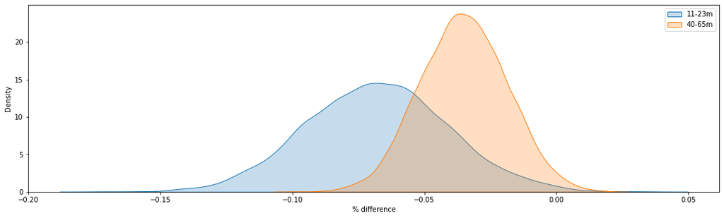

```python
# plot tenure groups
fig, ax = plt.subplots(figsize=(18,5))
for col in results.columns:
  sns.kdeplot(results[col], shade=True, label=col)
plt.xlabel('% difference')
plt.legend()
plt.show()
```

Commentary:

- Vast majority of the samples across both tenure groups exhibited a reduced churn rate
- Whilst the mean reduction is greater for 11-23m tenure, its' distribution is wider due to its smaller sample size (i.e. 602 vs. 824).

```python
# Calculating the probability that retention is greater when a customer is given a loyalty reward
print('probability that churn is lower with reward :', (results['11-23m'] < 0).sum() / len(results['11-23m']))

# confidence interval
print( 'confidence interval :' , np.round ( np.percentile( results['11-23m'], [5, 95] ) ,2) )
```

[output not shown]

```python
# Calculating the probability that retention is greater when a customer is given a loyalty reward
print('probability that churn is lower with reward :', (results['40-65m'] < 0).sum() / len(results['40-65m']))

# confidence interval
print('confidence interval :' ,np.round ( np.percentile( results['40-65m'], [5, 95] ) ,2) )
```

```
probability that churn is lower with reward : 0.9842
confidence interval : [-0.06 -0.01]
```

The probability that the loyalty rewards given to tenure groups 11-23m and 40-65m reduced churn is greater than 98%. We also estimate with 90% confidence that the true reduction in churn rate in percentage point terms is between 2% - 11% and 1% - 6% respectively.

In sum: we have strong reason to believe that the loyalty rewards provided to groups 11-23m and 40-65m are effective in reducing churn but caution should be taken as to the extent of the reduction they achieve due to the high level of variation, particularly when weighing up the cost/benefit of the programs. Increasing the sample size should help to reduce this uncertainty.

```python
!jupyter nbconvert --to html ABTest_ReducingChurn.ipynb
```

[output not shown]